# Lab 7_Solutions

## Lab 7

In this lab we will practice working with raster data, in this case in the context of climate models. I have given you 4 sets of data:

1. Climate Model Data_Historic - this is a NetCDF file with output from a climate model. Data is monthly average air temperature for 1920-2005
2. Climate Model Data_Future - this is a NetCDF file with climate model output for the period 2006-2080
3. Observed Temp Data - this is gridded data based on weather station and satellite data. Data is monthly for 1991-2000
4. Population data - gridded counts of population for a number of years

The first part of the lab will compare modeled and observed climate data for major cities around the world. The second part of the lab will combine the population data and future climate data to project future changes in global temperature.

### Part 1

1a. Read in the historic climate model data as a SpatRaster. Use “TREFHT” (temperature at reference height) in the subds (sub-dataset) argument.

```r
library(terra)
```

```r
hist_temp <- rast("Climate Model Data_Historic/b.e11.B20TRC5CNBDRD.f09_g16.002.cam.h0.TREFHT.192001-200512.nc", subds = "TREFHT")
```

1b. Use `ext` to see the longitude and latitude range of the SpatRaster you created. Note that the longitude goes form 0 to 360 (ish) instead of the more typical -180 to 180. This will cause a problem later on so use the `rotate` function to change the longitude coordinates. Use extent again on the rotated object to check the longitude goes from -180 to 180 (ish)

```r
hist_temp <- rotate(hist_temp)
ext(hist_temp)
```

```
## SpatExtent : -180.625, 179.375, -90.4712041884817, 90.4712041884817 (xmin, xmax, ymin, ymax)
```

2a. Use `rnaturalearth::ne_download()` function to get a SpatVector object of major cities (“populated_places”), and subset it to get just the 10 most populous cities based on 2020 population (POP2020 column)

```r
#Hint 1: Check the object type of the POP2020 column. If necessary convert to a numeric vector using as.numeric()

#Hint 2: The function order() will give you the index value corresponding to the ascending or descending numerical order of a column

library(rnaturalearth)

cities <- ne_download(scale = 50,
                      type = "populated_places",
                      category = "cultural",
                      returnclass = "sv")
```

```
## Reading 'ne_50m_populated_places.zip' from naturalearth...
```

```r
cities$POP2020 <- as.numeric(cities$POP2020)


top10 <- cities[order(cities$POP2020, decreasing = TRUE)[1:10], ]
```

2b. Make a plot of the temperature data for January 1920 and overlay the 10 major cities.

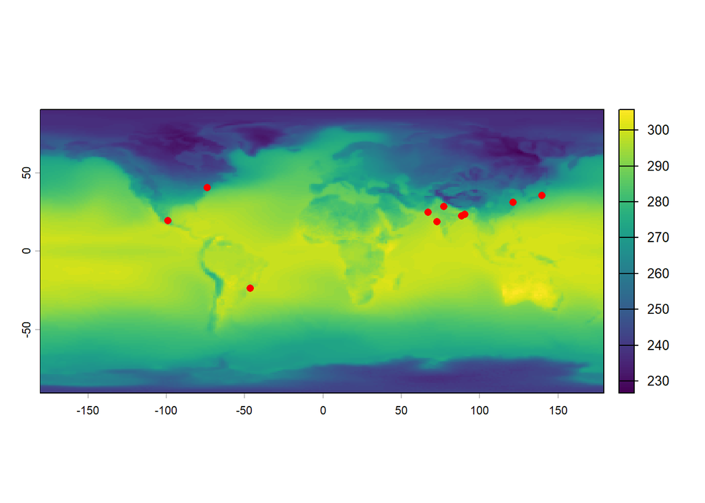

```r
plot(hist_temp[[1]])
plot(top10, add = TRUE, col = "red", pch =16)
```

2c. What about the plot gives you confidence this is actually showing temperature data from a January? Use code to show the units of the temperature data?

**Answer:**

```r
units(hist_temp)
```

[output not shown]

[output cut: 43 more lines]

```r
## K = Kelvin (temperature)
```

3a. Read in the observed temperature data as a SpatRaster, using “tmp” for the sub-dataset argument

```r
obs_temp <- rast("Observed Temp Data/cru_ts4.03.1991.2000.tmp.dat.nc",
                 subds = "tmp")

obs_temp <- rotate(obs_temp)
```

```
## |---------|---------|---------|---------|=========================================
```

3b. Note that this climate model data is for 1920-2005 but the observation data is only from 1991-2000. Subset the climate model data to just the years 1991-2000. Also change the units to match those of the observed climate data.

```r
# hint: have a look at ?terra::time to see how to get years

yrs <- as.numeric(format(time(hist_temp),"%Y"))
layers_1991_2000 <- which(yrs >=1991 & yrs <= 2000)
hist_1991_2000 <- hist_temp[[layers_1991_2000]]
hist_1991_2000 <- hist_1991_2000 - 273.15
```

4. Use `terra::extract` to produce two data-frames, one with observed and one with modeled temperature values for each city. Change the units of the modeled data so they match the units of the observed data.

```r
city_obs <- extract(obs_temp, top10)
city_sim <- extract(hist_1991_2000, top10)
```

We have to do a bit of data-wrangling to compare modeled and observed temperature data for each city.

5a. Add a column to both data-frames with the names of the cities using the NAME column from the city data frame

```r
city_obs <- city_obs[, -1]
city_sim <- city_sim[, -1]

city_obs <-as.data.frame(t(city_obs))
city_sim <-as.data.frame(t(city_sim))


colnames(city_obs) <- top10$NAME
colnames(city_sim) <- top10$NAME

city_obs$time <- time(obs_temp)
city_sim$time <- time(hist_1991_2000)
```

5b. Use `tidyr::pivot_longer` to turn both data-frames into tidy data-frames, with one row for each unique city-month combination

```r
#Hint: you want to use the first 10 columns (cities) to pivot (cols argument in the pivot_longer function). Use the values_to argument to name the temperature data column either "observed" or "simulated".

library(tidyr)
city_obs <- pivot_longer(city_obs,
                         cols = 1:10,
                         names_to = "city",
                         values_to = "observed")

city_sim <- pivot_longer(city_sim,
                         cols = 1:10,
                         names_to = "city",
                         values_to = "simulated")
```

5c. Notice that the modeled and observed rasters have used slightly different conventions for naming the months. You can see this in the “name” column of the two data frames you made in 5b. The model output uses the first of the month (e.g. 1991.02.01) whereas the observational data uses the middle of the month (e.g. 1991.01.16). This is a problem since we want to merge together the two data frames to compare observed and simulated data.

To merge the two data frames together, first we need to “chop off” the last two digits in the month ids in both data frames. One way to do this is to use the `substr` function to return some subset of a character vector.